# Kate’s Free Week at Camp: DataCamp, Introduction to the Tidyverse

# Table of Contents

# 1. Introduction to the Tidyverse

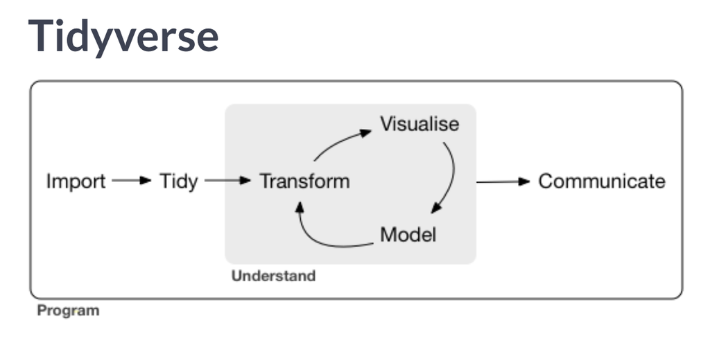

tidyverse figure1

# 2. Filter Verb

atomic step you use to filter data

you will always accompany it with a pipe

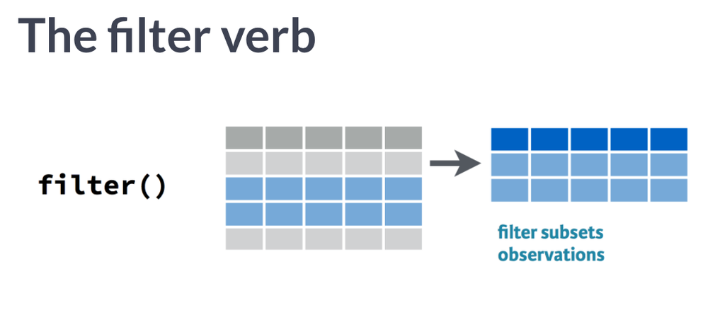

tidyverse figure2

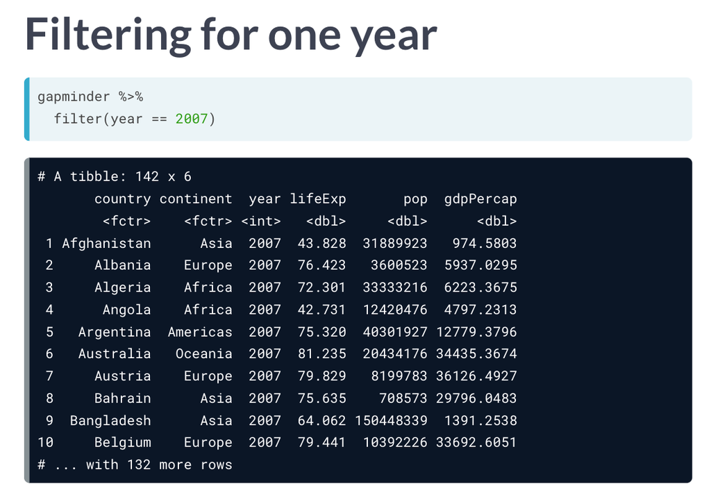

tidyverse figure3

Example:

```r
library(gapminder)
library(dplyr)

# Filter for China in 2002
gapminder %>%
  filter(country == "China", year == 2002)
```

Solution

```r
# > library(gapminder)
# > library(dplyr)
# >
# > # Filter for China in 2002
# > gapminder %>%
#     filter(country == "China", year == 2002)
# # A tibble: 1 x 6
#   country continent  year lifeExp        pop gdpPercap
#   <fct>   <fct>     <int>   <dbl>      <int>     <dbl>
# 1 China   Asia       2002    72.0 1280400000     3119.
```

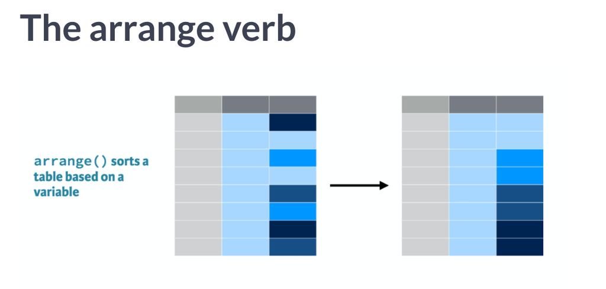

tidyverse figure4

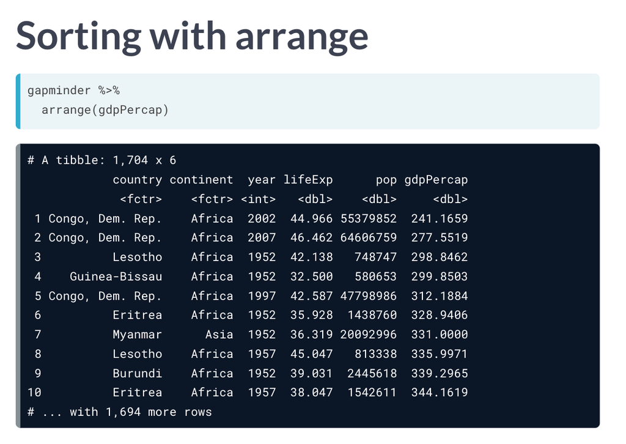

tidyverse figure5

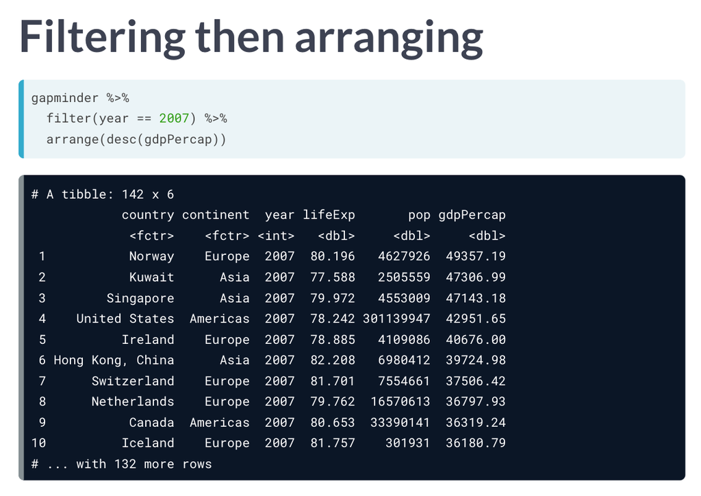

the arrange function defaults to accending order Example:

```r
library(gapminder)
library(dplyr)

# Sort in ascending order of lifeExp
gapminder %>%
  arrange(lifeExp)

# Sort in descending order of lifeExp
gapminder %>%
  arrange(desc(lifeExp))
```

# 3. Mutate Function

you create a new variable based on certain conditions in existing variables

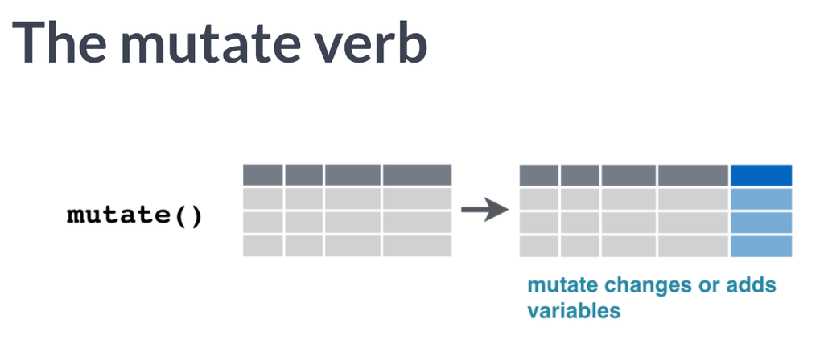

tidyverse figure4

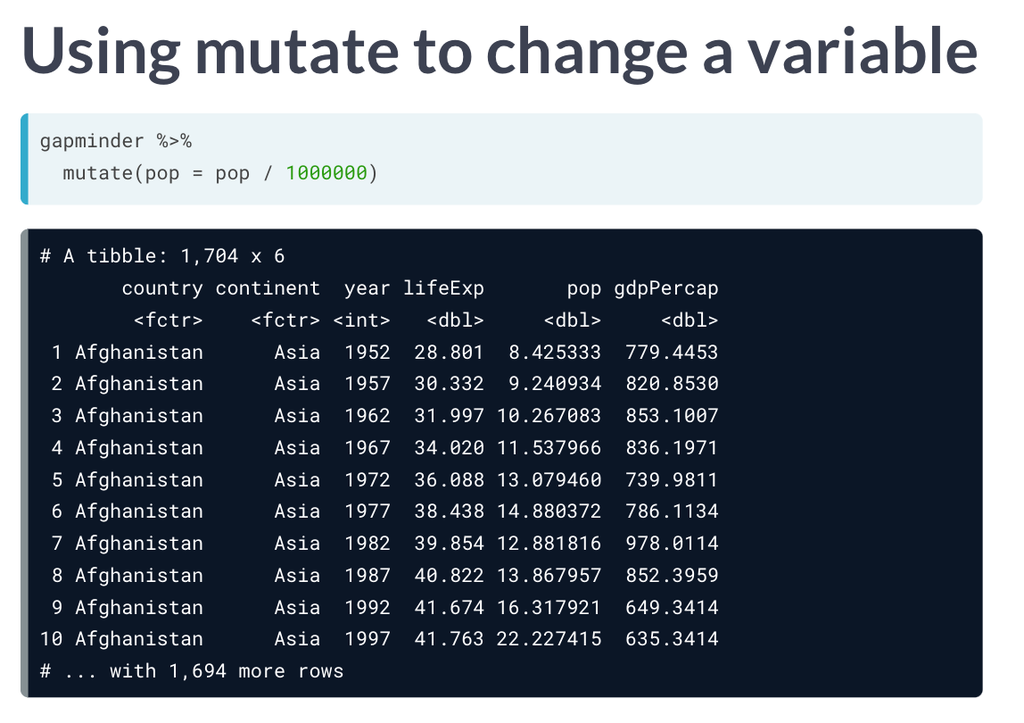

tidyverse figure5

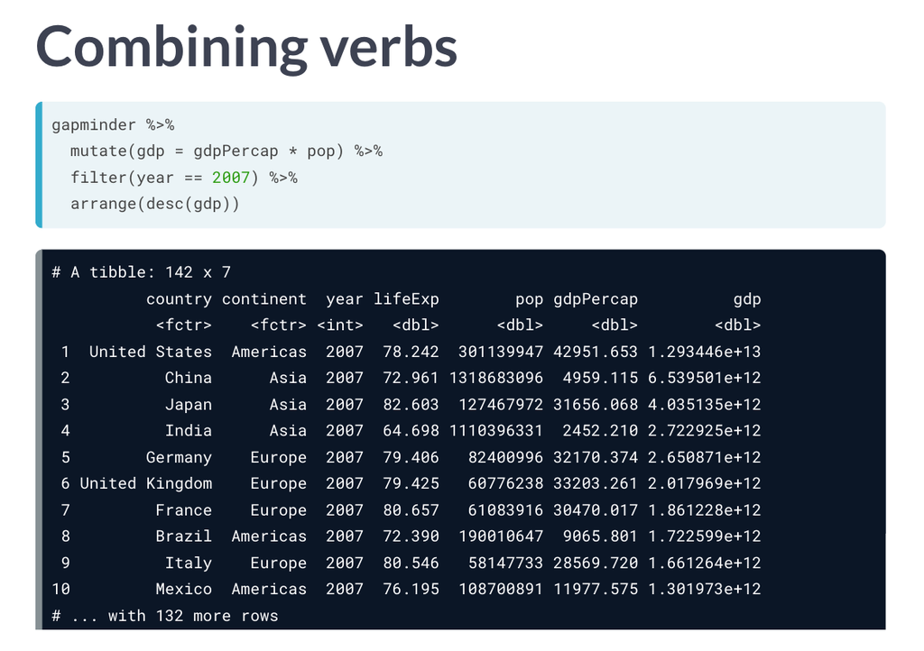

tidyverse figure6

Example

```r
library(gapminder)
library(dplyr)

# Use mutate to change lifeExp to be in months
gapminder %>%
  mutate(lifeExp = lifeExp * 12)

# Use mutate to create a new column called lifeExpMonths
gapminder %>%
  mutate(lifeExpMonths = lifeExp * 12)
```

Solution

```r
# > library(gapminder)
# > library(dplyr)
# >
```

[output not shown]

```r
# > gapminder %>%
#     mutate(lifeExp = lifeExp * 12)
# # A tibble: 1,704 x 6
#    country     continent  year lifeExp      pop gdpPercap
#    <fct>       <fct>     <int>   <dbl>    <int>     <dbl>
#  1 Afghanistan Asia       1952    346.  8425333      779.
#  2 Afghanistan Asia       1957    364.  9240934      821.
#  3 Afghanistan Asia       1962    384. 10267083      853.
#  4 Afghanistan Asia       1967    408. 11537966      836.
#  5 Afghanistan Asia       1972    433. 13079460      740.
#  6 Afghanistan Asia       1977    461. 14880372      786.
#  7 Afghanistan Asia       1982    478. 12881816      978.
#  8 Afghanistan Asia       1987    490. 13867957      852.
#  9 Afghanistan Asia       1992    500. 16317921      649.
# 10 Afghanistan Asia       1997    501. 22227415      635.
# # ... with 1,694 more rows
# >
# > # Use mutate to create a new column called lifeExpMonths
# > gapminder %>%
#     mutate(lifeExpMonths = lifeExp * 12)
# # A tibble: 1,704 x 7
#    country     continent  year lifeExp      pop gdpPercap lifeExpMonths
#    <fct>       <fct>     <int>   <dbl>    <int>     <dbl>         <dbl>
#  1 Afghanistan Asia       1952    28.8  8425333      779.          346.
#  2 Afghanistan Asia       1957    30.3  9240934      821.          364.
#  3 Afghanistan Asia       1962    32.0 10267083      853.          384.
#  4 Afghanistan Asia       1967    34.0 11537966      836.          408.
#  5 Afghanistan Asia       1972    36.1 13079460      740.          433.
#  6 Afghanistan Asia       1977    38.4 14880372      786.          461.
#  7 Afghanistan Asia       1982    39.9 12881816      978.          478.
#  8 Afghanistan Asia       1987    40.8 13867957      852.          490.
#  9 Afghanistan Asia       1992    41.7 16317921      649.          500.
# 10 Afghanistan Asia       1997    41.8 22227415      635.          501.
# # ... with 1,694 more rows
```

# 4. ggplot2

visualizing data with a graph

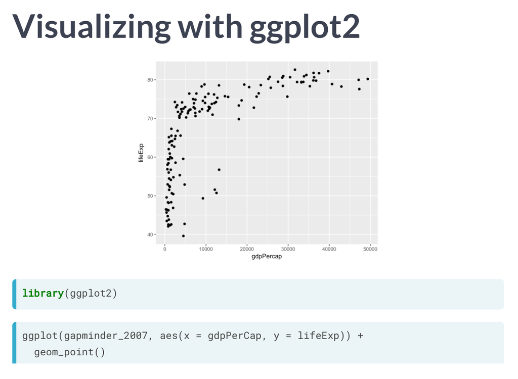

## 4.1 Overview of ggplots

There are three parts to a ggplot graph the dataframe the aesthetics the geometric object utilized

geom referes to a type of geometric object

Example

```r
library(gapminder)
library(dplyr)
library(ggplot2)

gapminder_1952 <- gapminder %>%
  filter(year == 1952)

# Create a scatter plot with pop on the x-axis and lifeExp on the y-axis
ggplot(gapminder_1952, aes(x = pop, y = lifeExp)) +
  geom_point()
```

Solution

```r
# > library(gapminder)
# > library(dplyr)
# > library(ggplot2)
# >
# > gapminder_1952 <- gapminder %>%
#     filter(year == 1952)
# >
# > # Create a scatter plot with pop on the x-axis and lifeExp on the y-axis
# > ggplot(gapminder_1952, aes(x = pop, y = lifeExp)) +
#     geom_point()
```

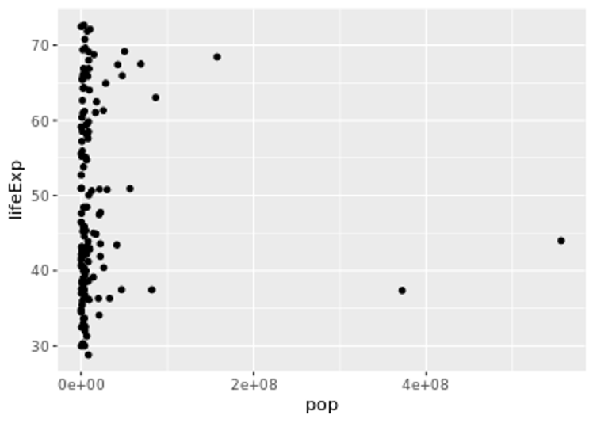

tidyverse figure8

## 4.2 log scales and ggplot2

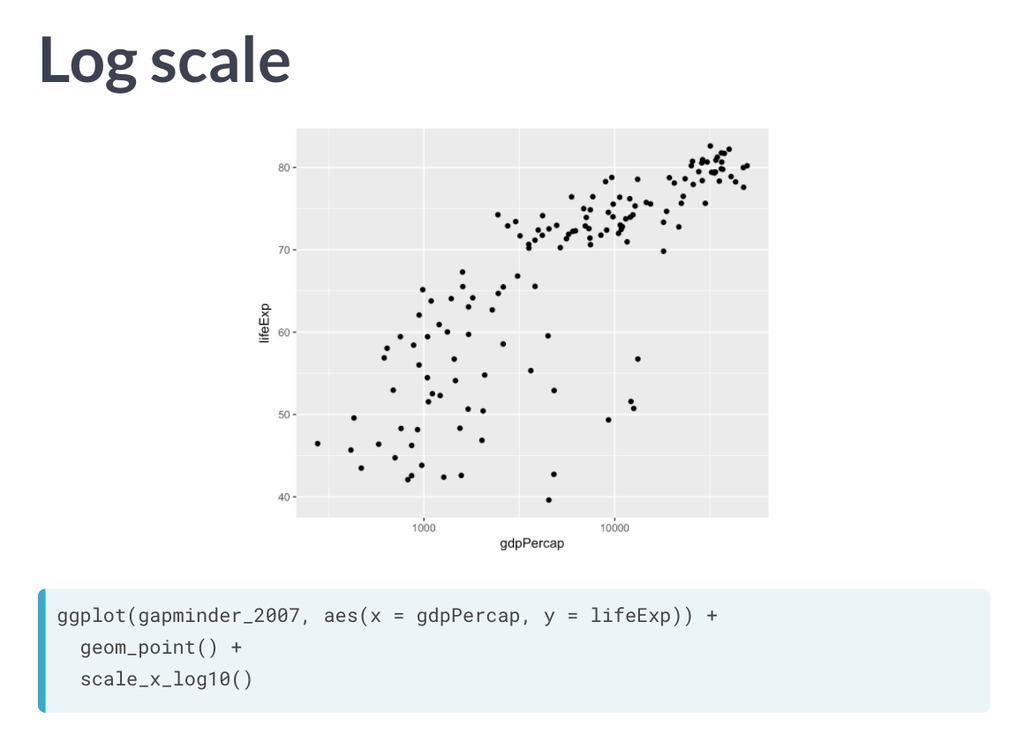

tidyverse figure9

## 4.3 additional aesthics

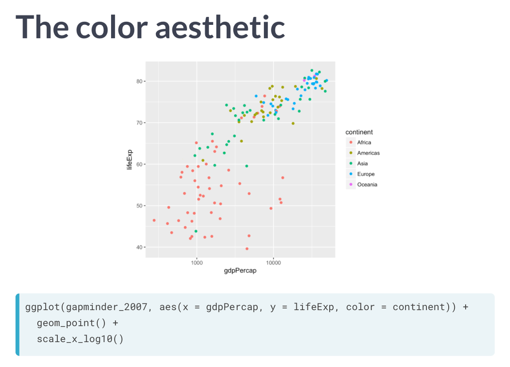

tidyverse figure10

### color doesn’t have the letter u inside it

## 4.4 Faceting

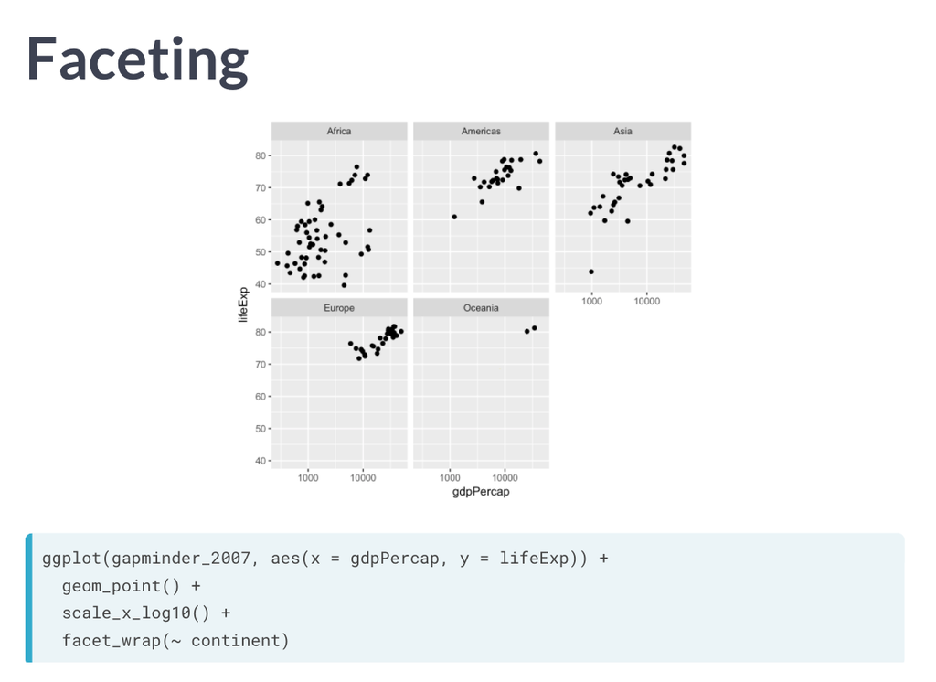

tidyverse figure10

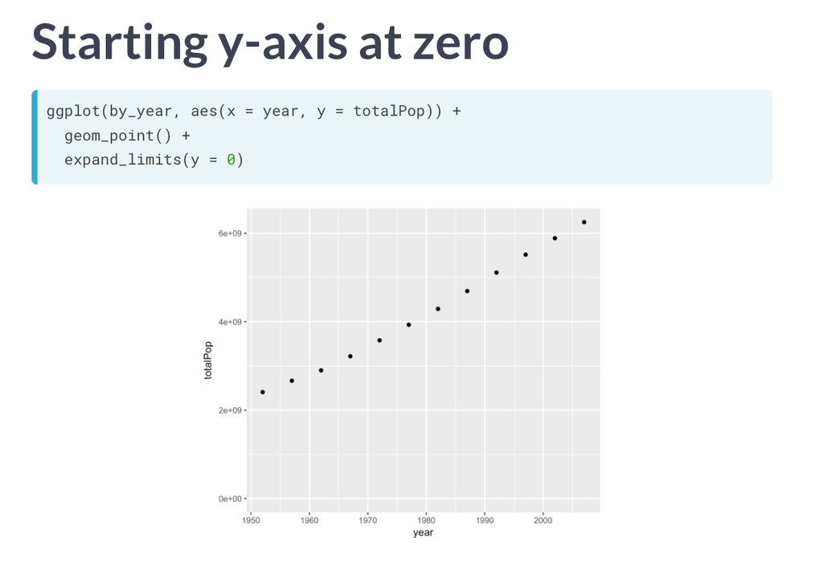

tidyverse figure16

# 5. Summarize

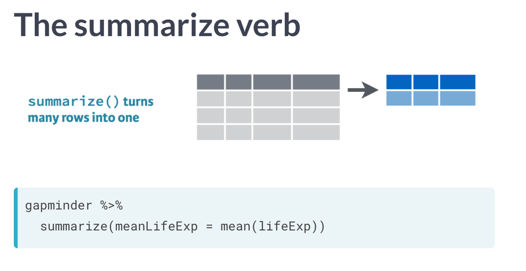

tidyverse figure11

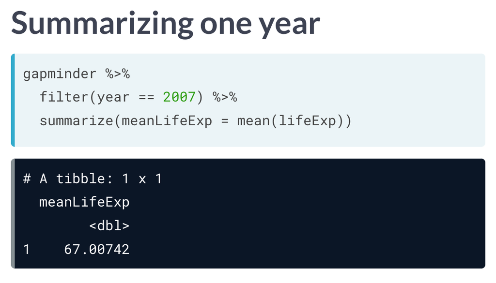

note the new value totalPop after the comma

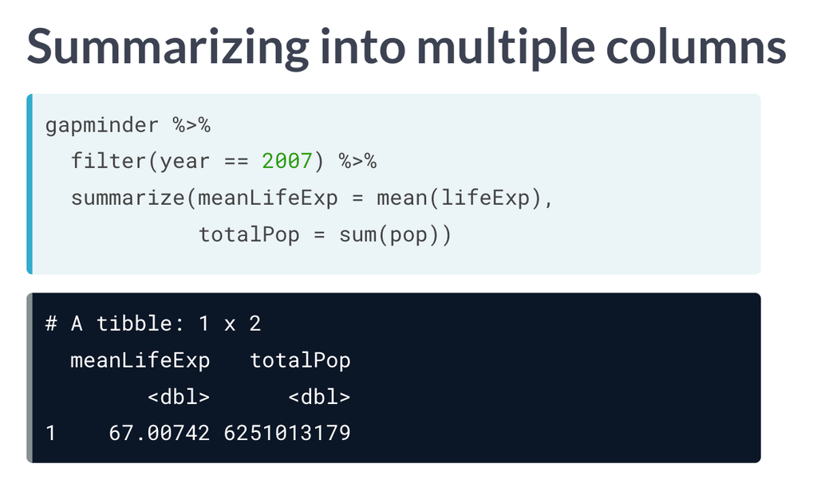

tidyverse figure14

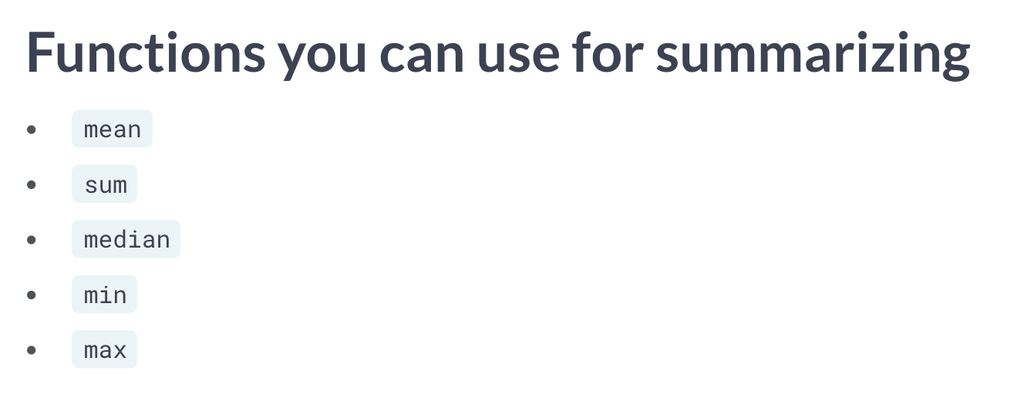

tidyverse figure15

Summarizing the median life expectancy You’ve seen how to find the mean life expectancy and the total population across a set of observations, but mean() and sum() are only two of the functions R provides for summarizing a collection of numbers. Here, you’ll learn to use the median() function in combination with summarize().